# Data Science Capstone

Milestone Report

Russ Bjork

1/7/2021

## Overview:

This is a milestone report for the Data Science Capstone project. The goal of  
this milestone report is to display a fundamental level of familiarity with  
the raw data and a direction with a prediction algorithm. The information  
presented will include a thorough exploratory analysis followed by a plan for  
creating the prediction algorithm and Shiny application. Tables and plots will  
be presented to illustrate important summaries of the data.

## The Data:

The raw data used for this project came from SwiftKey. The data will be  
utilized in conjunction Natural Language Processing techniques to make a predictive  
model. The data is from a corpus called HC Corpora. The data is provided in four  
LOCALEs, the four locales include: en_US, de_DE, ru_RU and fi_FI. This project  
will only utilize the English corpora.

Capstone Data: https://d396qusza40orc.cloudfront.net/dsscapstone/dataset/Coursera-SwiftKey.zip

The unified document corpus will be compiled from the following three sources  
of text data:

- Twitter
- News
- Blogs

# Environment Configuration:

Loading required packages and libraries. Configuring specific knitr parameters.  
Clearing the environment workspace to free up memory and resources.

## Initial review of the raw data files:

Each of the US locale files will be opened and a few lines will be pulled to get  
an initial feel for the data. The initial data look drives the full data loads  
followed by the data exploration. This quick look helps solidify an understanding  
of the data structures and general layout. This initial peek shows how much  
larger the news and blog lines are compared to the twitter lines.

en_US.twitter.txt File:

```
## [1] "How are you? Btw thanks for the RT. You gonna be in DC anytime soon? Love to see you. Been way, way too long."
## [2] "When you meet someone special... you'll know. Your heart will beat more rapidly and you'll smile for no reason."
## [3] "they've decided its more fun if I don't."
## [4] "So Tired D; Played Lazer Tag & Ran A LOT D; Ughh Going To Sleep Like In 5 Minutes ;)"
## [5] "Words from a complete stranger! Made my birthday even better :)"
```

en_US.news.txt File:

```
## [1] "He wasn't home alone, apparently."
## [2] "The St. Louis plant had to close. It would die of old age. Workers had been making cars there since the onset of mass automotive production in the 1920s."
## [3] "WSU's plans quickly became a hot topic on local online sites. Though most people applauded plans for the new biomedical center, many deplored the potential loss of the building."
## [4] "The Alaimo Group of Mount Holly was up for a contract last fall to evaluate and suggest improvements to Trenton Water Works. But campaign finance records released this week show the two employees donated a total of $4,500 to the political action committee (PAC) Partners for Progress in early…
## [5] "And when it's often difficult to predict a law's impact, legislators should think twice before carrying any bill. Is it absolutely necessary? Is it an issue serious enough to merit their attention? Will it definitely not make the situation worse?"
```

en_US.blogs.txt File:

```
## [1] "In the years thereafter, most of the Oil fields and platforms were named after pagan â\200œgodsâ\200\235."
## [2] "We love you Mr. Brown."
## [3] "Chad has been awesome with the kids and holding down the fort while I work later than usual! The kids have been busy together playing Skylander on the XBox together, after Kyan cashed in his $$$ from his piggy bank. He wanted that game so bad and used his gift card from his birthday he has b…
## [4] "so anyways, i am going to share some home decor inspiration that i have been storing in my folder on the puter. i have all these amazing images stored away ready to come to life when we get our home."
## [5] "With graduation season right around the corner, Nancy has whipped up a fun set to help you out with not only your graduation cards and gifts, but any occasion that brings on a change in one's life. I stamped the images in Memento Tuxedo Black and cut them out with circle Nestabilities. I emb…
```

## Initiate a full data load:

### Loading the entire dataset to initiate some exploration

The twitter, news, and blogs data will be loaded in entirety to begin a summarization  
of the raw data. This step will help shed insights on the data layout, design, and  
general structure.

## Summarization of the data from the three text files:

In preparation to construct the unified document corpus and clean the data, a basic  
summary of the three text files has been constructed. This summary includes file  
sizes, number of lines, number of characters, and number of words for each  
source file. Some basic statistics on the number of words per line  
has been summarized.

Data Files Summary

| Files | File Size | Characters | Words | WPL Min | WPL Mean | WPL Max | Lines |
| --- | --- | --- | --- | --- | --- | --- | --- |
| en_US.twitter.txt | 159 MB | 162096241 | 30451170 | 1 | 13 | 47 | 2360148 |
| en_US.news.txt | 196 MB | 15639408 | 2651432 | 1 | 35 | 1123 | 77259 |
| en_US.blogs.txt | 200 MB | 206824505 | 37570839 | 0 | 42 | 6726 | 899288 |

## Plotting out the summary of each data file:

### Plot of words per line for Twitter data:

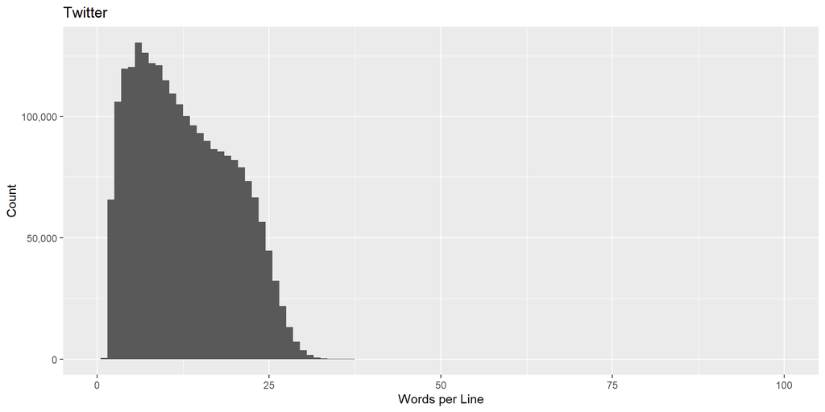

### Plot of words per line for News data:

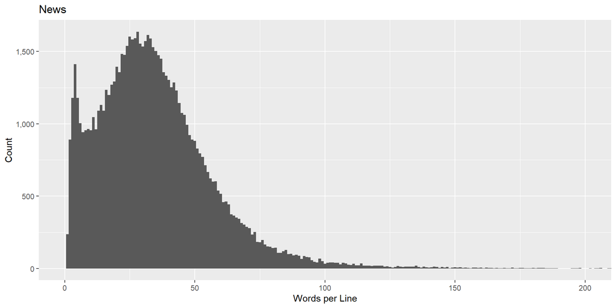

### Plot of words per line for Blogs data:

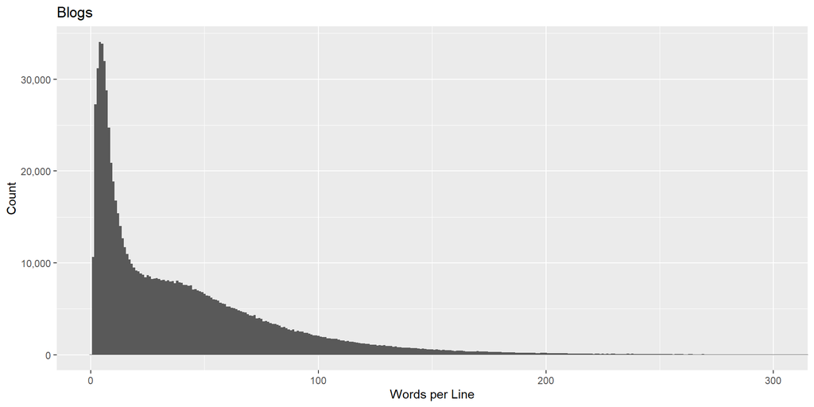

## Data Transformation and Exploration:

After constructing the sample file, the data will be transformed to remove all  
unusable constructs. This transformation process will leave us with a tidy data  
file required prior to formal exploration. The following elements will be removed  
from the sample file:

- Remove white space
- Remove Twitter handles
- Convert text to lowercase
- Remove punctuation
- Remove numbers
- Remove Stop Words
- Remove profanity
- Convert to plain text
- Remove URLs

### Exploration - Word Relevance:

Exploratory data analysis will be performed to fulfill the primary goal for  
this report. Several techniques will be employed to develop an understanding of  
the training data which include looking at the most frequently used words,  
tokenizing and n-gram generation.

First 10 Lines - Tidy Data

| dying read thisiswhereileaveyou supposed hysterical |
| --- |
| ifplab web developing thank |
| game pregame news kobe sick dog birdman go clear internet history advantage |
| wish la running dunkin oh beautiful bayous rt ff wish runnin louisiana |
| rt lesson learned confab cmss treated like garbage disposal bad content repackaged still bad content |
| popi tragic comedic time fathers love children wanting better life us |
| yum sat june pm aespos tables going mass ave |
| feels like trick question like guessing may like curly hair get tired |
| getting ready san antonio goodwills council executives happy speaking topic equation innovation |
| songs u hear pin drop dude slurping drink delimag residency |

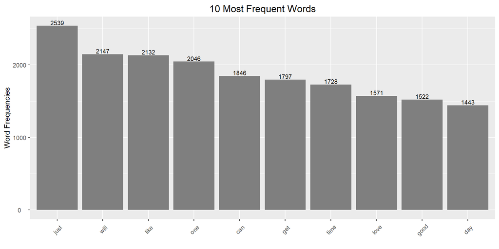

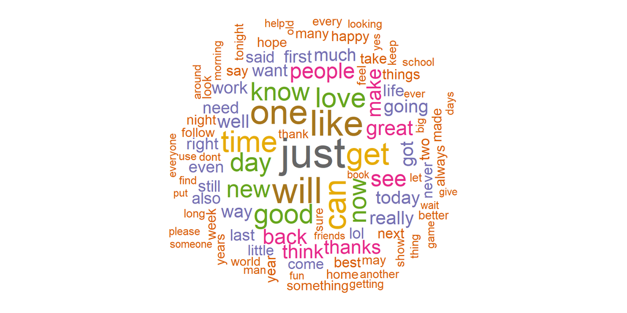

# Tokenize and build the N-Grams:

## Unigram visualization -

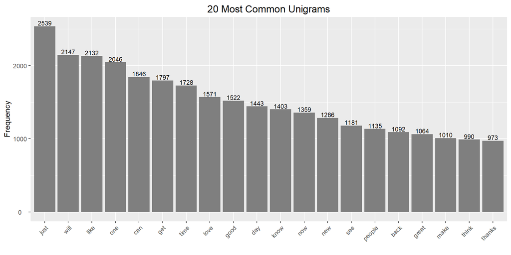

## Bigram visualization -

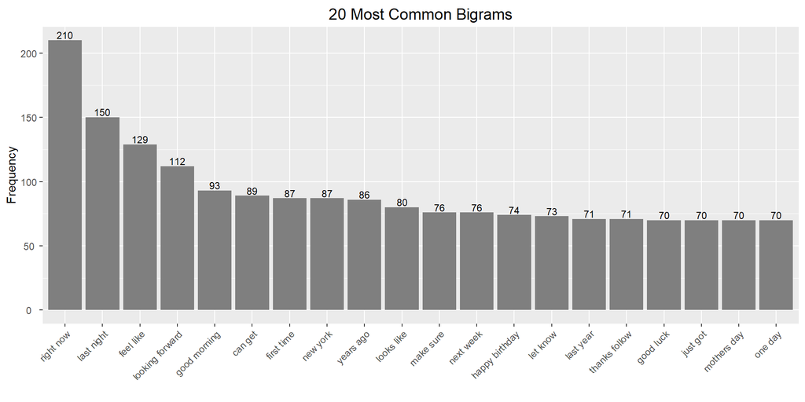

## Trigram visualization -

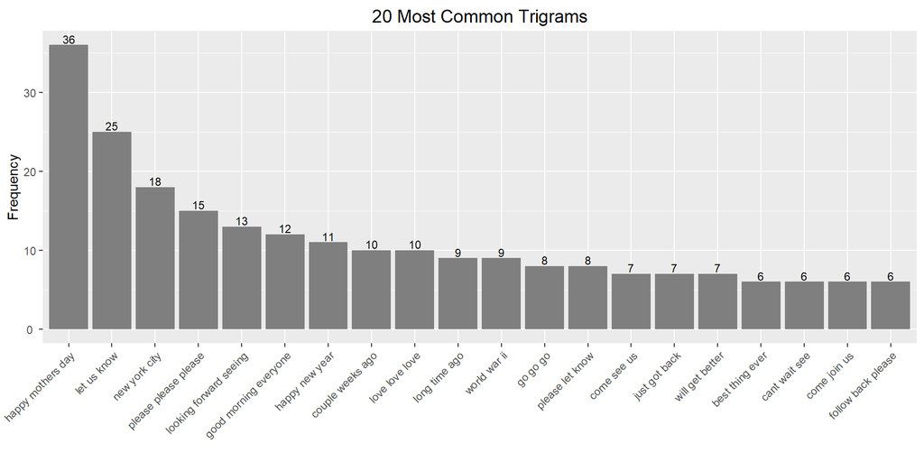

## Prediction Model - N-Gram System:

The predictive model to be developed will utilize the Shiny application. The  
Shiny application will be designed to interface a model engine designed around  
uniqrams, bigrams, and trigrams. The `RWeka` package will be utilized in order  
to construct functions that tokenize the sample data and construct matrices of  
uniqrams, bigrams, and trigrams.

## Conclusion:

The capstone project will conclude with a predictive algorithm that will be  
interfaced using a Shiny application. The Shiny application will provide the  
user interface. Structurally, the Shiny app will take as input a phrase or  
sequence of words in a text box input and generate as output a prediction  
of the next word.

The predictive algorithm will be developed using an n-gram model with a  
word frequency look up. This is same approach utilized in the exploratory data  
analysis. The algorithm strategy will be based on the results realized and  
gathered during the exploratory analysis. Such that, as n increased for  
each n-gram, the frequency decreased for each of its terms. A possible algorithm  
strategy may be to construct the model to first look for the unigram that would  
follow from the entered text. Once a full term is input and followed by a space,  
the algorithm would identify the most common bigram model and so on.

Another possible strategy may be to predict the next word using the trigram  
model. If no matching trigram can be found, then the algorithm would check the  
bigram model. If still not found, use the unigram model.